# Assignment 10: Predictive Modeling - Part 1

*How to do it?*:

- Open the Rmarkdown file of this assignment (link) in Rstudio.
- Right under each **question**, insert a code chunk (you can use the hotkey `Ctrl + Alt + I` to add a code chunk) and code the solution for the question.
- `Knit` the rmarkdown file (hotkey: `Ctrl + Alt + K`) to export an html.
- Publish the html file to your Githiub Page.

*Submission*: Submit the link on Github of the assignment to Canvas

1. Use the `Adult Census Income` dataset. We will predict the income (whether or not it is more than 50k or not) of an adult. Import the dataset. Partition the data into 80% training and 20% testing.

```r
library(tidyverse)

df <- read_csv('adult_census_missing.csv')

df <- df %>%
  rename(target=income) %>%
  mutate(target = as.factor(target),
         sex = as.factor(sex))

mean_age <- mean(df$age, na.rm=TRUE)
df$Age <- replace_na(df$age, mean_age)

df <- df %>% drop_na()
```

```r
library(caret)
set.seed(2020)
splitIndex <- createDataPartition(df$target, p = .80,
                                  list = FALSE)
df_train1 <- df[ splitIndex,]
df_test1 <- df[-splitIndex,]
```

2. Practice Decision Tree. Do the follows:
- Use `rpart` package, create a decision tree with maximum depth of 3.
- Calculate the accuracy of the model on the testing data. Notice that the positive outcome here is not `1` but `>50K` or `<50K`.
- Plot the tree
- Plot the variable importance by the tree

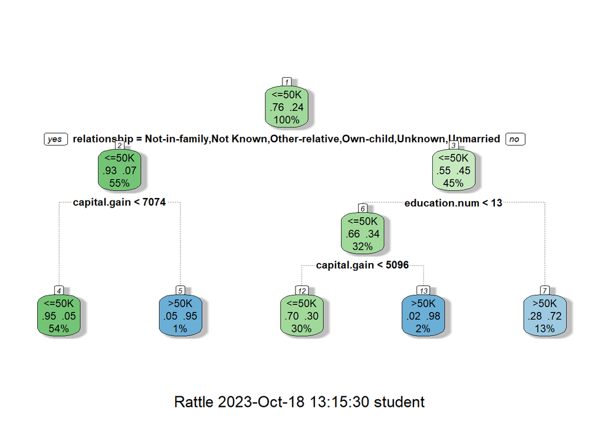

```r
library(rpart)
library(rattle)

tree_model1 <- rpart(target ~ ., data = df_train1,
                    control = rpart.control(maxdepth = 3))

fancyRpartPlot(tree_model1)
```

```r
tree_model1$variable.importance
```

```
##   relationship marital.status   capital.gain  education.num      education
##     1903.82974     1869.91065      840.78648      727.02028      725.77395
##            sex     occupation            age            Age native.country
##      596.49132      531.38287      440.62506      440.62506       15.37129
##   capital.loss
##       10.59372
```

```r
pred <- predict(tree_model1, df_test1, type = "class")

df_test1$target <- factor(df_test1$target, levels = levels(pred))

cm1 <- confusionMatrix(data = pred, reference = df_test1$target, positive = ">50K")
cm1$overall[1]
```

```
##  Accuracy
## 0.8474236
```

3. Create 3 more trees and compare the testing accuracy of these trees, which tree give the highest testing accuracy.

```r
set.seed(2017)
splitIndex <- createDataPartition(df$target, p = .80,
                                  list = FALSE)
df_train2 <- df[ splitIndex,]
df_test2 <- df[-splitIndex,]

tree_model2 <- rpart(target ~ ., data = df_train2,
                    control = rpart.control(maxdepth = 3))

pred2 <- predict(tree_model2, df_test2, type = "class")

df_test2$target <- factor(df_test2$target, levels = levels(pred2))

cm2 <- confusionMatrix(data = pred2, reference = df_test2$target, positive = ">50K")
cm2$overall[1]
```

```
## Accuracy
##  0.83971
```

```r
set.seed(2007)
splitIndex <- createDataPartition(df$target, p = .80,
                                  list = FALSE)
df_train3 <- df[ splitIndex,]
df_test3 <- df[-splitIndex,]

tree_model3 <- rpart(target ~ ., data = df_train3,
                    control = rpart.control(maxdepth = 3))

pred3 <- predict(tree_model3, df_test3, type = "class")

df_test3$target <- factor(df_test3$target, levels = levels(pred3))

cm3 <- confusionMatrix(data = pred3, reference = df_test3$target, positive = ">50K")
cm3$overall[1]
```

```
##  Accuracy
## 0.8452638
```

```r
set.seed(2029)
splitIndex <- createDataPartition(df$target, p = .80,
                                  list = FALSE)
df_train4 <- df[ splitIndex,]
df_test4 <- df[-splitIndex,]

tree_model4 <- rpart(target ~ ., data = df_train4,
                    control = rpart.control(maxdepth = 3))

pred4 <- predict(tree_model4, df_test4, type = "class")

df_test4$target <- factor(df_test4$target, levels = levels(pred4))

cm4 <- confusionMatrix(data = pred4, reference = df_test4$target, positive = ">50K")
cm4$overall[1]
```

```
##  Accuracy
## 0.8449553
```

```r
library(randomForest)

forest_model1 <- randomForest(target ~ ., data=df_train1, ntree=500)
pred <- predict(forest_model1, df_test1, type = 'class')

cm <- confusionMatrix(data = pred, reference = df_test1$target, positive = '>50K')

cm$overall[1]
```

```
##  Accuracy
## 0.8657822
```

5. Create 3 more forests and compare the testing accuracy of these forests, which forest give the highest testing accuracy.

```r
forest_model2 <- randomForest(target ~ ., data=df_train2, ntree=500)
pred <- predict(forest_model2, df_test1, type = 'class')

cm <- confusionMatrix(data = pred, reference = df_test1$target, positive = '>50K')

cm$overall[1]
```

```
##  Accuracy
## 0.9413761
```

```r
forest_model3 <- randomForest(target ~ ., data=df_train3, ntree=500)
pred <- predict(forest_model3, df_test1, type = 'class')

cm <- confusionMatrix(data = pred, reference = df_test1$target, positive = '>50K')

cm$overall[1]
```

```
##  Accuracy
## 0.9438445
```

```r
forest_model4 <- randomForest(target ~ ., data=df_train4, ntree=500)
pred <- predict(forest_model4, df_test1, type = 'class')

cm <- confusionMatrix(data = pred, reference = df_test1$target, positive = '>50K')

cm$overall[1]
```

```
##  Accuracy
## 0.9473928
```